# Recap of class 3

- Recap of class 3 topics
- Class 3 homework review

At this point you should have enough knowledge to import, explore, visualize, and wrangle data in R! You should also have a good understanding of all the fundamentals you need to branch out and start learning how to do more specialized tasks on your own. Those are all the tough parts - from here on out, classes can focus on more practical applications of the tool.

# Data Analysis Fundamentals

- The most important part in answering a question is: Clearly defining the question!
- Data comes second - identify and collect it
- Data cleaning is commonly overlooked but absolutely critical for valid conclusions
- Once you have a question and a relevant, clean dataset then run your analysis by creating models, testing hypotheses, building visualizations, etc.
- If you come up with predictions, attempt to validate them
- Finally, create your output and document your work - make it as reproducible as possible/practical

# Practical exercises

Note: From now on, it’s assumed you understand how to install packages if you do not already have them installed. Also you should be able to find and review relevant documentation.

In this practice exercise, will answer the questions or complete tasks posed below using datasets from the nycflights13 library: Q1: What was the fastest NYC flight in 2013? Q2: What airlines are most delayed on average? Q3: Create a chart that visually describes delays by airline Q4: Do delays correlate with greater speed in-flight? Q5: Does weather significantly affect flight delay severity?

Load required packages

```r
library(tidyverse)
library(nycflights13)
```

Explore the data

```r
# ?flights
df <- flights
summary(df)
```

```
##       year          month             day           dep_time
##  Min.   :2013   Min.   : 1.000   Min.   : 1.00   Min.   :   1
##  1st Qu.:2013   1st Qu.: 4.000   1st Qu.: 8.00   1st Qu.: 907
##  Median :2013   Median : 7.000   Median :16.00   Median :1401
##  Mean   :2013   Mean   : 6.549   Mean   :15.71   Mean   :1349
##  3rd Qu.:2013   3rd Qu.:10.000   3rd Qu.:23.00   3rd Qu.:1744
##  Max.   :2013   Max.   :12.000   Max.   :31.00   Max.   :2400
##                                                  NA's   :8255
##  sched_dep_time   dep_delay          arr_time    sched_arr_time
##  Min.   : 106   Min.   : -43.00   Min.   :   1   Min.   :   1
##  1st Qu.: 906   1st Qu.:  -5.00   1st Qu.:1104   1st Qu.:1124
##  Median :1359   Median :  -2.00   Median :1535   Median :1556
##  Mean   :1344   Mean   :  12.64   Mean   :1502   Mean   :1536
##  3rd Qu.:1729   3rd Qu.:  11.00   3rd Qu.:1940   3rd Qu.:1945
##  Max.   :2359   Max.   :1301.00   Max.   :2400   Max.   :2359
##                 NA's   :8255      NA's   :8713
##    arr_delay          carrier              flight       tailnum
##  Min.   : -86.000   Length:336776      Min.   :   1   Length:336776
##  1st Qu.: -17.000   Class :character   1st Qu.: 553   Class :character
##  Median :  -5.000   Mode  :character   Median :1496   Mode  :character
##  Mean   :   6.895                      Mean   :1972
##  3rd Qu.:  14.000                      3rd Qu.:3465
##  Max.   :1272.000                      Max.   :8500
##  NA's   :9430
##     origin              dest              air_time        distance
##  Length:336776      Length:336776      Min.   : 20.0   Min.   :  17
##  Class :character   Class :character   1st Qu.: 82.0   1st Qu.: 502
##  Mode  :character   Mode  :character   Median :129.0   Median : 872
##                                        Mean   :150.7   Mean   :1040
##                                        3rd Qu.:192.0   3rd Qu.:1389
##                                        Max.   :695.0   Max.   :4983
##                                        NA's   :9430
##       hour           minute        time_hour
##  Min.   : 1.00   Min.   : 0.00   Min.   :2013-01-01 05:00:00
##  1st Qu.: 9.00   1st Qu.: 8.00   1st Qu.:2013-04-04 13:00:00
##  Median :13.00   Median :29.00   Median :2013-07-03 10:00:00
##  Mean   :13.18   Mean   :26.23   Mean   :2013-07-03 05:02:36
##  3rd Qu.:17.00   3rd Qu.:44.00   3rd Qu.:2013-10-01 07:00:00
##  Max.   :23.00   Max.   :59.00   Max.   :2013-12-31 23:00:00
##
```

```r
str(df)
```

```
## Classes 'tbl_df', 'tbl' and 'data.frame':    336776 obs. of  19 variables:
##  $ year          : int  2013 2013 2013 2013 2013 2013 2013 2013 2013 2013 ...
##  $ month         : int  1 1 1 1 1 1 1 1 1 1 ...
##  $ day           : int  1 1 1 1 1 1 1 1 1 1 ...
##  $ dep_time      : int  517 533 542 544 554 554 555 557 557 558 ...
##  $ sched_dep_time: int  515 529 540 545 600 558 600 600 600 600 ...
##  $ dep_delay     : num  2 4 2 -1 -6 -4 -5 -3 -3 -2 ...
##  $ arr_time      : int  830 850 923 1004 812 740 913 709 838 753 ...
##  $ sched_arr_time: int  819 830 850 1022 837 728 854 723 846 745 ...
##  $ arr_delay     : num  11 20 33 -18 -25 12 19 -14 -8 8 ...
##  $ carrier       : chr  "UA" "UA" "AA" "B6" ...
##  $ flight        : int  1545 1714 1141 725 461 1696 507 5708 79 301 ...
##  $ tailnum       : chr  "N14228" "N24211" "N619AA" "N804JB" ...
##  $ origin        : chr  "EWR" "LGA" "JFK" "JFK" ...
##  $ dest          : chr  "IAH" "IAH" "MIA" "BQN" ...
##  $ air_time      : num  227 227 160 183 116 150 158 53 140 138 ...
##  $ distance      : num  1400 1416 1089 1576 762 ...
##  $ hour          : num  5 5 5 5 6 5 6 6 6 6 ...
##  $ minute        : num  15 29 40 45 0 58 0 0 0 0 ...
##  $ time_hour     : POSIXct, format: "2013-01-01 05:00:00" "2013-01-01 05:00:00" ...
```

Q1: What was the fastest NYC flight in 2013?

```r
df <- flights
df %>%
  mutate(speed = distance/air_time) %>%
  filter(speed == max(speed, na.rm = TRUE))# %>%
```

```
## # A tibble: 1 x 20
##    year month   day dep_time sched_dep_time dep_delay arr_time
##   <int> <int> <int>    <int>          <int>     <dbl>    <int>
## 1  2013     5    25     1709           1700         9     1923
## # ... with 13 more variables: sched_arr_time <int>, arr_delay <dbl>,
## #   carrier <chr>, flight <int>, tailnum <chr>, origin <chr>, dest <chr>,
## #   air_time <dbl>, distance <dbl>, hour <dbl>, minute <dbl>,
## #   time_hour <dttm>, speed <dbl>
```

```r
  #View()
```

Q2: What airlines are most delayed on average?

```r
df <- flights
df %>%
  mutate(total_delay = dep_delay + arr_delay) %>%
  group_by(carrier) %>%
  summarise(Average_Delay = mean(total_delay, na.rm = TRUE)) %>%
  left_join(airlines) %>%
  select(Airline = name,
         Airline_Code = carrier,
         Average_Delay) %>%
  arrange(desc(Average_Delay))
```

```
## # A tibble: 16 x 3
##                        Airline Airline_Code Average_Delay
##                          <chr>        <chr>         <dbl>
##  1      Frontier Airlines Inc.           F9     42.121880
##  2 AirTran Airways Corporation           FL     38.721890
##  3    ExpressJet Airlines Inc.           EV     35.635360
##  4          Mesa Airlines Inc.           YV     34.455882
##  5      Southwest Airlines Co.           WN     27.310777
##  6       SkyWest Airlines Inc.           OO     24.517241
##  7           Endeavor Air Inc.           9E     23.819244
##  8             JetBlue Airways           B6     22.425521
##  9                   Envoy Air           MQ     21.220114
## 10       United Air Lines Inc.           UA     15.574920
## 11              Virgin America           VX     14.521110
## 12        Delta Air Lines Inc.           DL     10.868291
## 13      American Airlines Inc.           AA      8.933421
## 14             US Airways Inc.           US      5.874288
## 15      Hawaiian Airlines Inc.           HA     -2.014620
## 16        Alaska Airlines Inc.           AS     -4.100141
```

Q3: Create a chart that visually describes delays by airline

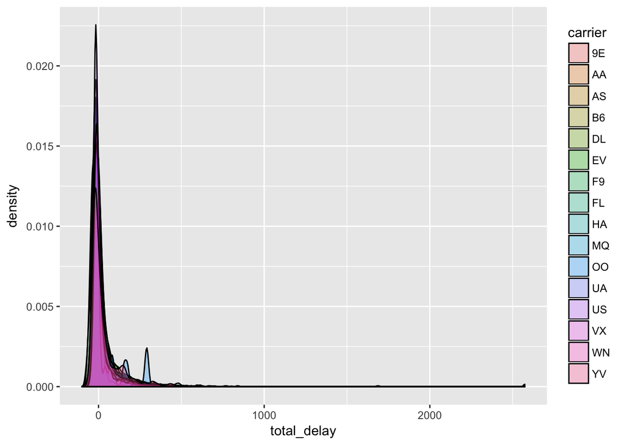

```r
df <- flights
carrier_dep_delay <- df %>%
  mutate(total_delay = dep_delay + arr_delay) %>%
  filter(!is.na(total_delay))

ggplot(data = carrier_dep_delay, aes(x = total_delay, fill = carrier)) +
  geom_density(alpha = .3)
```

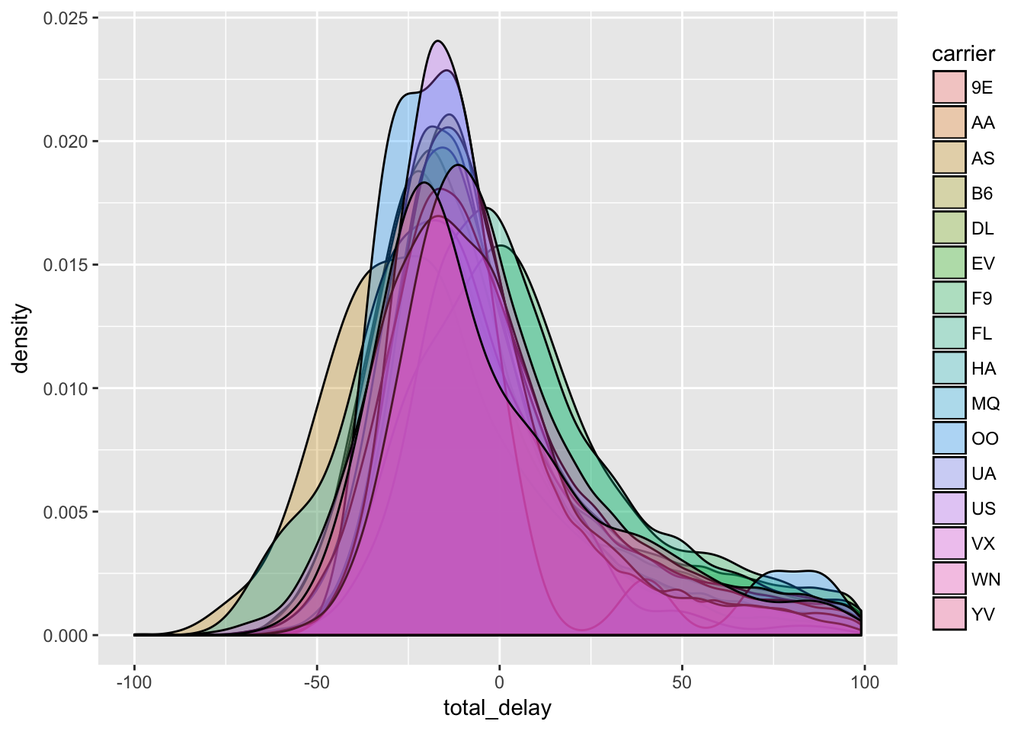

```r
# For easier viewing, remove all departures >=100min
carrier_dep_delay %>%
  filter(total_delay < 100) %>%
  ggplot(data = ., aes(x = total_delay, fill = carrier)) +
    geom_density(alpha = .3)
```

Q4: Do delays correlate with greater speed in-flight?

```r
df <- flights
df <- df %>%
  mutate(total_delay = dep_delay + arr_delay) %>%
  mutate(speed = distance/air_time)

cor_x <- df %>%
  filter(!is.na(total_delay)) %>%
  select(total_delay)

cor_y <- df %>%
  filter(!is.na(speed)) %>%
  select(speed)

# Do a correlation for the two variables
cor(cor_x, cor_y)
```

```
##                   speed
## total_delay -0.07655684
```

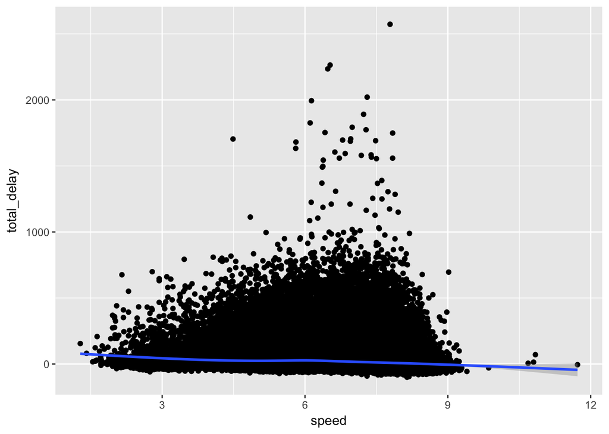

```r
# Create a visualization
ggplot(data = df, aes(x = speed, y = total_delay)) +
  geom_point() +
  geom_smooth()
```

Q5:Does weather significantly affect flight delay severity?

```r
# TBD
```

# Homework

For this class, complete the following homework assignments:

- Finish answering any open questions from this problem set; otherwise, ask more questions that could be answered with the nycflights13 dataset and practice answering them
- Read Tidy Data and A Layered Grammar of Graphics, both by Hadley Wickham
- Now that your data is imported and cleaned up, begin working on the script that will answer your research question; you should have everything you need to extract conclusions related to your project!